# Lab 4 — Data Visualization

Author

Arnav Bhatia

Published

October 2, 2026

## Setup

This report examines the association between weekly average dew point and wind speed in four regions of the continental United States and by elevation category.

If needed, run the following command once in the R console before rendering this document:

```r
install.packages(c("tidyverse", "leaflet", "Hmisc", "ggforce"))
```

```r
library(tidyverse)
library(leaflet)
library(Hmisc)
library(ggforce)

theme_set(theme_bw(base_size = 12))

region_colors <- c(
  "NW" = "#1B9E77",
  "SW" = "#D95F02",
  "NE" = "#7570B3",
  "SE" = "#E7298A"
)
```

## 1. Read in the data

```r
data_url <- paste0(
  "https://raw.githubusercontent.com/USCbiostats/",
  "data-science-data/master/02_met/met_all.gz"
)

if (!file.exists("met_all.gz")) {
  download.file(
    url = data_url,
    destfile = "met_all.gz",
    method = "libcurl",
    timeout = 60
  )
}

met <- read.csv("met_all.gz")

dim(met)
```

```
[1] 2377343      30
```

The original data contain 2,377,343 hourly observations and 30 variables.

## 2. Prepare the data

The cleaning steps below replace documented numeric missing-value codes with `NA`, remove temperatures below -17°C, create a date, retain the first seven days of the month, and calculate one weekly average for each station.

```r
key_variables <- c(
  "temp", "rh", "wind.sp", "vis.dist",
  "dew.point", "lat", "lon", "elev"
)

missing_codes <- c(999, 9999, 99999, 999999)

met_clean <- met |>
  mutate(
    across(
      all_of(key_variables),
      ~ replace(.x, .x %in% missing_codes, NA_real_)
    ),
    date = as.Date(paste(year, month, day, sep = "-"))
  ) |>
  filter(!is.na(temp), temp >= -17, day <= 7)

met_avg <- met_clean |>
  group_by(USAFID) |>
  summarise(
    across(
      all_of(key_variables),
      ~ mean(.x, na.rm = TRUE)
    ),
    .groups = "drop"
  ) |>
  mutate(
    # mean(..., na.rm = TRUE) returns NaN when a group is entirely missing.
    across(all_of(key_variables), ~ replace(.x, is.nan(.x), NA_real_)),
    region = case_when(
      lon <= -98 & lat >= 39.71 ~ "NW",
      lon <= -98 & lat <  39.71 ~ "SW",
      lon >  -98 & lat >= 39.71 ~ "NE",
      lon >  -98 & lat <  39.71 ~ "SE",
      TRUE ~ NA_character_
    ),
    elev_cat = case_when(
      elev <= 252 ~ "Low",
      elev > 252  ~ "High",
      TRUE ~ NA_character_
    ),
    region = factor(region, levels = c("NW", "SW", "NE", "SE")),
    elev_cat = factor(elev_cat, levels = c("Low", "High"))
  )

summary(met_avg[, key_variables])
```

```
      temp              rh           wind.sp           vis.dist
 Min.   :-17.00   Min.   :14.82   Min.   : 0.1165   Min.   : 3904
 1st Qu.: 22.24   1st Qu.:65.31   1st Qu.: 1.4395   1st Qu.:14166
 Median : 24.28   Median :74.65   Median : 2.0894   Median :15238
 Mean   : 24.47   Mean   :70.31   Mean   : 2.2189   Mean   :14851
 3rd Qu.: 26.64   3rd Qu.:80.49   3rd Qu.: 2.8707   3rd Qu.:15840
 Max.   : 39.46   Max.   :95.64   Max.   :10.2957   Max.   :83369
                  NAs    :1       NAs    :12        NAs    :26
   dew.point           lat             lon               elev
 Min.   :-2.206   Min.   :24.56   Min.   :-124.29   Min.   : -12.0
 1st Qu.:15.514   1st Qu.:33.90   1st Qu.: -99.15   1st Qu.:  89.0
 Median :18.207   Median :38.06   Median : -91.74   Median : 237.0
 Mean   :17.586   Mean   :37.69   Mean   : -92.63   Mean   : 416.2
 3rd Qu.:21.168   3rd Qu.:41.68   3rd Qu.: -82.57   3rd Qu.: 402.5
 Max.   :26.120   Max.   :48.94   Max.   : -68.31   Max.   :4110.5
 NAs    :1                                          NAs    :2
```

```r
table(met_avg$region, useNA = "ifany")
```

```
 NW  SW  NE  SE
147 297 484 653
```

```r
table(met_avg$elev_cat, useNA = "ifany")
```

```
 Low High <NA>
 829  750    2
```

After cleaning and aggregation, the analysis contains 1,581 weather stations.

## 3. Relative humidity and dew point by region

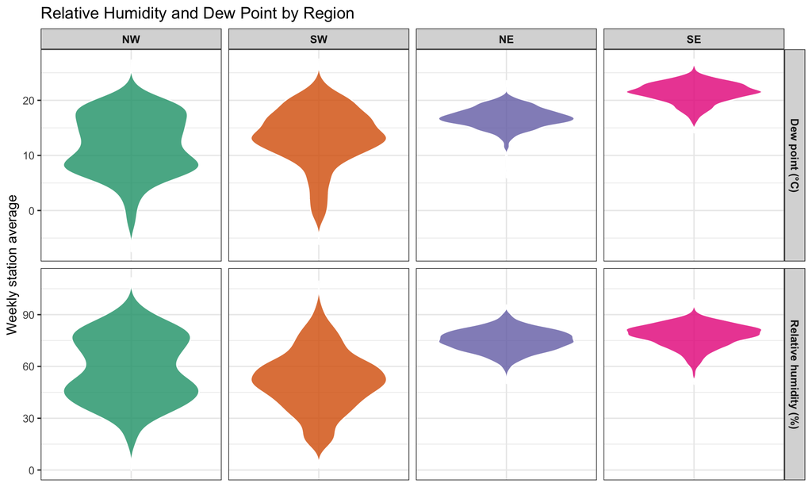

Figure 1: Distributions of weekly average relative humidity and dew point by US region.

```r
ggplot(violin_data, aes(x = factor(1), y = value, fill = region)) +
  geom_violin(trim = FALSE, alpha = 0.8, color = "white") +
  facet_grid(variable ~ region, scales = "free_y") +
  scale_fill_manual(values = region_colors, guide = "none") +
  labs(
    title = "Relative Humidity and Dew Point by Region",
    x = NULL,
    y = "Weekly station average"
  ) +
  theme(
    axis.text.x = element_blank(),
    axis.ticks.x = element_blank(),
    strip.text = element_text(face = "bold")
  )
```

The violin widths show where station averages are most concentrated, while their vertical extent shows the range. Average relative humidity is highest in the **SE** and lowest in the **SW**. Average dew point is highest in the **SE** and lowest in the **NW**. Differences in violin width and length also indicate that the variables do not have identical variability across the four regions.

## 4. Association between dew point and relative humidity

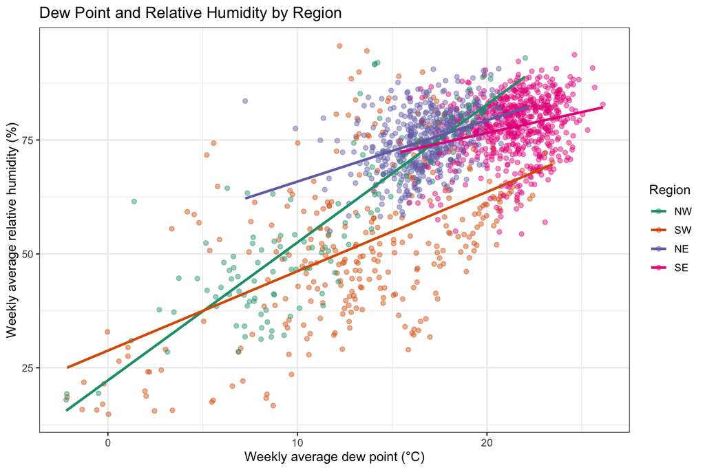

Figure 2: Association between weekly average dew point and relative humidity, with a separate fitted linear regression line for each region.

```r
ggplot(
  scatter_data,
  aes(x = dew.point, y = rh, color = region)
) +
  geom_point(alpha = 0.45, size = 1.7) +
  stat_smooth(method = "lm", se = FALSE, linewidth = 1.1) +
  scale_color_manual(values = region_colors) +
  labs(
    title = "Dew Point and Relative Humidity by Region",
    x = "Weekly average dew point (°C)",
    y = "Weekly average relative humidity (%)",
    color = "Region"
  )
```

The estimated relationship between dew point and relative humidity is **positive in every region**. Based on the absolute within-region correlation, the strongest linear association occurs in the **NW**. The vertical separation among the fitted lines indicates that stations with the same dew point may nevertheless have different expected relative humidity depending on region.

```r
association_summary |>
  mutate(
    correlation = round(correlation, 3),
    slope = round(slope, 3)
  ) |>
  knitr::kable(
    col.names = c("Region", "Correlation", "Regression slope"),
    caption = "Within-region dew point and relative humidity associations"
  )
```

Within-region dew point and relative humidity associations

| Region | Correlation | Regression slope |
| --- | --- | --- |
| NW | 0.873 | 3.027 |
| SW | 0.531 | 1.741 |
| NE | 0.400 | 1.344 |
| SE | 0.255 | 0.916 |

## 5. Weather stations by elevation category and region

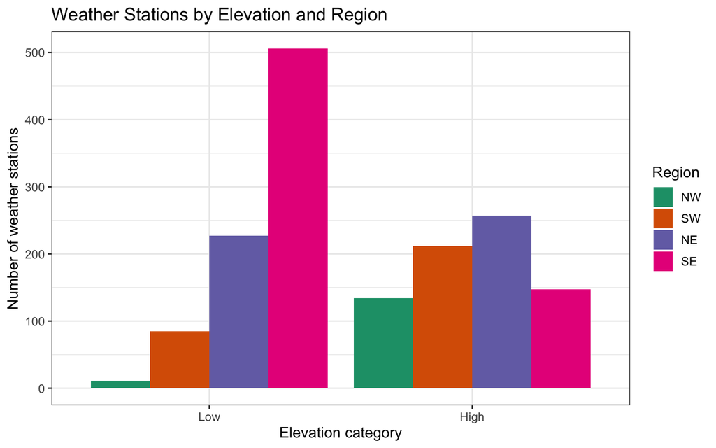

Figure 3: Weather-station counts by elevation category and region.

```r
ggplot(bar_data, aes(x = elev_cat, fill = region)) +
  geom_bar(position = "dodge") +
  scale_fill_brewer(palette = "Dark2") +
  labs(
    title = "Weather Stations by Elevation and Region",
    x = "Elevation category",
    y = "Number of weather stations",
    fill = "Region"
  )
```

The largest combination is **SE–Low**, with 506 stations. The smallest observed combination is **NW–Low**, with 11 stations. The plot therefore shows that the distribution of sampled stations across elevation categories is not the same in all four regions.

## 6. Mean dew point and wind speed by region

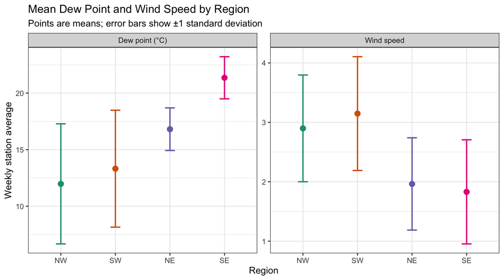

Figure 4: Regional means with error bars extending one standard deviation above and below each mean.

```r
ggplot(weather_long, aes(x = region, y = value, color = region)) +
  stat_summary(
    fun.data = "mean_sdl",
    fun.args = list(mult = 1),
    geom = "point",
    size = 3
  ) +
  stat_summary(
    fun.data = "mean_sdl",
    fun.args = list(mult = 1),
    geom = "errorbar",
    width = 0.18,
    linewidth = 0.8
  ) +
  facet_wrap(~ variable, scales = "free_y") +
  scale_color_manual(values = region_colors, guide = "none") +
  labs(
    title = "Mean Dew Point and Wind Speed by Region",
    subtitle = "Points are means; error bars show ±1 standard deviation",
    x = "Region",
    y = "Weekly station average"
  )
```

**Dew point is** highest on average in the **SE** and lowest in the **NW**.

**Wind speed is** highest on average in the **SW** and lowest in the **SE**. Longer error bars represent greater between-station variability within a region. Overlapping standard-deviation intervals indicate that there is considerable within-region variation, so the graph alone should not be treated as a formal significance test.

## 7. Spatial trend in relative humidity

```r
map_data <- met_avg |>
  drop_na(lat, lon, rh) |>
  mutate(
    rh_rank = rank(-rh, ties.method = "first"),
    top10 = rh_rank <= 10
  )

rh_palette <- colorNumeric(
  palette = c("#FFF7BC", "#7FCDBB", "#2C7FB8", "#253494"),
  domain = map_data$rh
)

spatial_summary <- map_data |>
  mutate(
    east_west = if_else(lon > -98, "East", "West"),
    north_south = if_else(lat >= 39.71, "North", "South")
  ) |>
  summarise(
    east = mean(rh[east_west == "East"], na.rm = TRUE),
    west = mean(rh[east_west == "West"], na.rm = TRUE),
    north = mean(rh[north_south == "North"], na.rm = TRUE),
    south = mean(rh[north_south == "South"], na.rm = TRUE)
  )

east_west_text <- if (
  spatial_summary$east > spatial_summary$west
) "East" else "West"

north_south_text <- if (
  spatial_summary$north > spatial_summary$south
) "North" else "South"
```

```r
top10_data <- map_data |>
  filter(top10)

leaflet(data = map_data) |>
  addProviderTiles("CartoDB.Positron") |>

  addCircleMarkers(
    lng = ~lon,
    lat = ~lat,
    radius = 4,
    stroke = FALSE,
    fillColor = ~rh_palette(rh),
    fillOpacity = 0.75,
    label = ~paste0(
      "Station: ", USAFID,
      " | RH: ", round(rh, 1), "%"
    )
  ) |>

  addCircleMarkers(
    data = top10_data,
    lng = ~lon,
    lat = ~lat,
    radius = 8,
    color = "#D7301F",
    weight = 3,
    fill = FALSE,
    label = ~paste0(
      "Top-10 station | RH: ",
      round(rh, 1),
      "%"
    )
  ) |>

  addLegend(
    position = "bottomright",
    pal = rh_palette,
    values = map_data$rh,
    title = "Relative humidity (%)",
    opacity = 1
  )
```

[interactive chart not shown]

Figure 5

The map shows geographic clustering rather than a uniform distribution of relative humidity. As a broad numerical comparison, average station humidity is higher in the **East** than in the other east–west half and higher in the **North** than in the other north–south half. The red outlined circles identify the ten stations with the highest weekly average relative humidity. These broad summaries should be interpreted alongside the local patterns visible on the interactive map.

## 8. Plot using a ggplot extension

For the extension plot, `ggforce::geom_sina()` displays individual stations while spreading overlapping points according to their local density. It therefore combines some of the strengths of a violin plot and a jittered point plot.

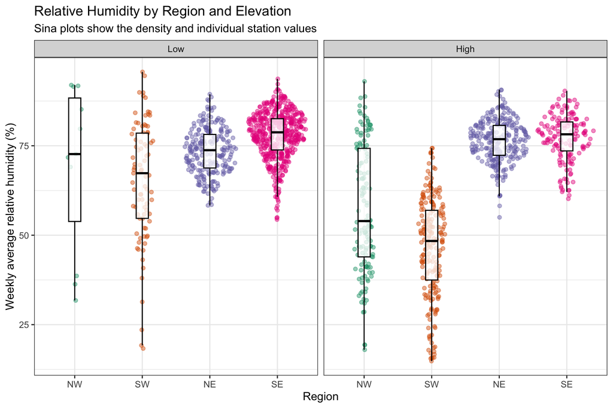

Figure 6: Distribution of relative humidity by region and elevation category using ggforce::geom_sina.

```r
met_avg |>
  drop_na(region, elev_cat, rh) |>
  ggplot(aes(x = region, y = rh, color = region)) +
  ggforce::geom_sina(alpha = 0.45, size = 1.6) +
  geom_boxplot(
    width = 0.18,
    outlier.shape = NA,
    color = "black",
    fill = "white",
    alpha = 0.75
  ) +
  facet_wrap(~ elev_cat) +
  scale_color_manual(values = region_colors, guide = "none") +
  labs(
    title = "Relative Humidity by Region and Elevation",
    subtitle = "Sina plots show the density and individual station values",
    x = "Region",
    y = "Weekly average relative humidity (%)"
  )
```

This extension plot makes it possible to compare both the center and the full distribution of station-level relative humidity. Wider sections contain a greater concentration of stations. Comparing the low- and high-elevation facets shows whether the regional humidity pattern remains similar across elevation categories.

## Conclusion

This analysis cleaned and summarized hourly meteorological records into weekly station averages. The visualizations compared relative humidity, dew point, wind speed, elevation, geographic region, and spatial location. Together, the figures demonstrate that weather conditions and the distribution of monitoring stations vary geographically across the continental United States.